# STA 141A: Course Final Project

Weishen Fang 918641603

2023-06-12

## 1 Abstract

This project is made with R markdown. To finish the project, we need to analyze the data of 18 sessions (Sessions 1 to 18) from four mice: Cori, Frossman, Hence, and Lederberg. The primary objective of this project is to build a predictive model to predict the outcome (feedback type) of each trial using the neural activity data (spike trains in spks), along with the stimuli (the left and right contrasts). To be more specific, the ultimate goal of the project is to predict the outcome (feedback_type) in the test set that contains 100 trials from Session 1 and Session 18. A total of 18 RDS files are provided that contain the records from 18 sessions. We can download these RDS files and the test data from the link provided on the Canvas course page.

## 2 Introduction

We need to analyze data from 18 sessions in this project. I find that there are 8 variables in each session. We can report mouse_name(the name of the mouse for specific sessions), date_exp(the date of the experiment), number of brain_area(the unique brain area involved), number of neurons, number of trials (the number of trials in each session), success rate for each session(the ratio of successful trials to the total number of trials) (6 in total). Data structure differs across sessions. For instance, Session 1 contains 734 neurons from 8 brain areas, where Session 2 contains 1070 neurons from 5 brain areas. Each session comprised several hundred trials. Following variables are available for each trial:

- feedback_type: type of the feedback, 1 for success and -1 for failure
- contrast_left: contrast of the left stimulus
- contrast_right: contrast of the right stimulus
- time: centers of the time bins for spks
- spks: numbers of spikes of neurons in the visual cortex in time bins defined in time
- brain_area: area of the brain where each neuron lives

Take the 11th trial in Session 5 for example, we can see that the left contrast for this trial is 1 the right contrast is 0, and the feedback (outcome) of the trial is 1. There are a total of 1077 meurons in this trial from 10 areas of the brain. The primary objective of this project is to build a predictive model to predict the outcome (feedback type) of each trial using the neural activity data (spike trains in spks), along with the stimuli (the left and right contrasts). To define neural activities, we can take the average number of spikes across neurons in each brain area as the activities. To develop my projects in the next sections, I’m thinking about some questions of interest:

- Is there a relationship between the contrast levels of the stimuli (left and right) and the feedback type (success or failure) in the trials? Can this relationship be used to predict the feedback type?
- How does the success rate vary across different mice and sessions?

  This question explores the overall performance of the mice and sessions. By examining the success rates in different sessions and for different mice, I can identify any variations or trends that might influence the outcome prediction and provide insights into the reliability of the data.
- Are there any interactions or relationships between the neural activity and the success rate across sessions?
- Can we predict the outcome (feedback type) of each trial based on the neural activity (e.g., average number of spikes, firing rate) and stimulus contrasts?

  This is the primary objective of my project. By building a predictive model using the neural activity data (spike trains) and stimulus contrasts as features, I aim to predict the feedback type (success or failure) of each trial. This question focuses on developing a reliable model for outcome prediction.
- Do different brain areas exhibit distinct patterns of neural activity during the decision-making process?

  This question explores the variability in neural activity across different brain areas. By comparing the activity patterns of neurons from different brain areas, I can investigate if certain areas play specific roles in decision-making.
- Are there specific brain areas or neurons that are more strongly associated with successful outcomes? Can the activity of these neurons be used to predict the feedback type?

## 3 Background

In the study conducted by Steinmetz et al. (2019), experiments were performed on a total of 10 mice over 39 sessions. Each session comprised several hundred trials, during which visual stimuli were randomly presented to the mouse on two screens positioned on both sides of it. The stimuli varied in terms of contrast levels, which took values in {0, 0.25, 0.5, 1}, with 0 indicating the absence of a stimulus. The mice were required to make decisions based on the visual stimuli, using a wheel controlled by their forepaws. A reward or penalty (i.e., feedback) was subsequently administered based on the outcome of their decisions. In particular,

- When left contrast > right contrast, success (1) if turning the wheel to the right and failure (-1) otherwise.
- When right contrast > left contrast, success (1) if turning the wheel to the left and failure (-1) otherwise.
- When both left and right contrasts are zero, success (1) if holding the wheel still and failure (-1) otherwise.
- When left and right contrasts are equal but non-zero, left or right will be randomly chosen (50%) as the correct choice.

The activity of the neurons in the mice’s visual cortex was recorded during the trials and made available in the form of spike trains, which are collections of timestamps corresponding to neuron firing. In this project, we focus specifically on the spike trains of neurons from the onset of the stimuli to 0.4 seconds post-onset. In addition, we only use 18 sessions (Sessions 1 to 18) from four mice: Cori, Frossman, Hence, and Lederberg.

## 4 Descriptive analysis

1. Describe the data structures across sessions.

```
## [1] FALSE
```

| Mouse_Name | Date_Exp | Num_Areas | Num_Neurons | Num_Trials | Success_Rate |
| --- | --- | --- | --- | --- | --- |
| Cori | 2016-12-14 | 8 | 734 | 114 | 0.61 |
| Cori | 2016-12-17 | 5 | 1070 | 251 | 0.63 |
| Cori | 2016-12-18 | 11 | 619 | 228 | 0.66 |
| Forssmann | 2017-11-01 | 11 | 1769 | 249 | 0.67 |
| Forssmann | 2017-11-02 | 10 | 1077 | 254 | 0.66 |
| Forssmann | 2017-11-04 | 5 | 1169 | 290 | 0.74 |
| Forssmann | 2017-11-05 | 8 | 584 | 252 | 0.67 |
| Hench | 2017-06-15 | 15 | 1157 | 250 | 0.64 |
| Hench | 2017-06-16 | 12 | 788 | 372 | 0.69 |
| Hench | 2017-06-17 | 13 | 1172 | 447 | 0.62 |
| Hench | 2017-06-18 | 6 | 857 | 342 | 0.80 |
| Lederberg | 2017-12-05 | 12 | 698 | 340 | 0.74 |
| Lederberg | 2017-12-06 | 15 | 983 | 300 | 0.80 |
| Lederberg | 2017-12-07 | 10 | 756 | 268 | 0.69 |
| Lederberg | 2017-12-08 | 8 | 743 | 404 | 0.76 |
| Lederberg | 2017-12-09 | 6 | 474 | 280 | 0.72 |
| Lederberg | 2017-12-10 | 6 | 565 | 224 | 0.83 |
| Lederberg | 2017-12-11 | 10 | 1090 | 216 | 0.81 |

- To explore data structures across sessions, I create a table using the kable() function from the knitr package. From the table, we can see the name of the mouse for each session, the date of the experiment for each session, the number of unique brain areas recorded in each session, the number of neurons recorded in each session, the number of trials conducted in each session, and the success rate of trials in each session which is calculated as the average feedback type value across trials. Those variables all have different values across 18 sessions. For instance, Session 1 contains 734 neurons from 8 brain areas, where Session 2 contains 1070 neurons from 5 brain areas.
2. Explore the neural activities during each trial.

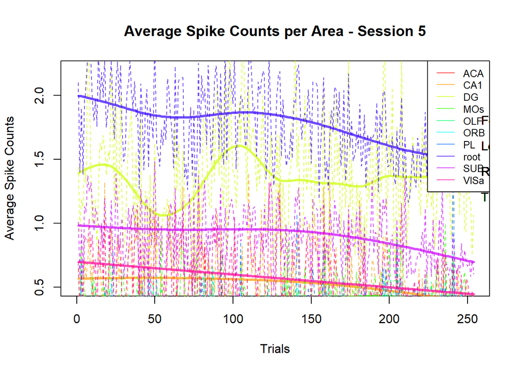

```
## # A tibble: 254 × 10
##      ACA   CA1    DG   MOs   OLF    ORB     PL  root   SUB  VISa
##    <dbl> <dbl> <dbl> <dbl> <dbl>  <dbl>  <dbl> <dbl> <dbl> <dbl>
##  1 0.302 0.643 1.44  0.241 0.331 0.375  0.214   2.10 1.01  0.697
##  2 0.189 0.25  0.938 0.414 0.260 0.312  0.0714  1.40 0.584 0.343
##  3 0.453 0.179 1.19  0.828 0.630 0.469  0.714   1.90 0.950 0.626
##  4 0.113 0.179 1.12  0.310 0.227 0.25   0.214   1.38 0.584 0.384
##  5 0.189 0.714 1.44  0.483 0.227 0.375  0.143   1.96 1.13  0.899
##  6 0.189 0.571 1.31  0.345 0.409 0.125  0       2.08 1.09  0.869
##  7 0.208 0.714 2.31  0.310 0.260 0.0938 0.214   2.33 1.38  0.848
##  8 0.189 0.893 2.25  0.172 0.309 0.281  0.143   2.28 1.25  1.04
##  9 0.208 0.536 1.44  0.276 0.315 0.156  0.429   2.27 1.32  0.778
## 10 0.528 0.75  1     0.586 0.569 0.438  0.357   1.98 1.16  0.909
## # ℹ 244 more rows
```

```
##       ACA       CA1        DG       MOs       OLF       ORB        PL      root
## 0.2796761 0.5233408 1.3427657 0.3863698 0.3108931 0.2923228 0.2168166 1.7618185
##       SUB      VISa
## 0.9023544 0.5716217
```

- From the table in section 4.1, We can see that there are 254 trails and 10 brain areas in session 5. I explore the neural activities during each trial in session 5 by showing the number of spikes in every trial for 10 brain areas, the average spike counts per brain area, and the plot of average spike counts per area in session 5. The different colored lines in the plot correspond to distinct brain areas recorded in session 5. The legend on the top right of the plot provides the names of 10 brain areas and we can identify which brain areas are associated with each line by referring to the legend.The plot also shows the variation in the average spike counts across different brain areas and each line represents the average spike counts for a specific brain area. The lines exhibit different patterns and shapes, indicating variations in neural activity across brain areas.The smooth curves fitted to the lines provide a visual representation of the overall trends in the average spike counts per trial for each brain area. We can observe the general patterns of neural activity for different brain areas throughout the session 5. In the plot for session 5, brain area root has the highest average spike counts which means area root has greatest neural activity or firing rate, indicating that a larger number of neurons in root area are firing more frequently or producing more action potentials during the recorded trials in session 5. On the other hand, brain area PL has the lowest average spike counts which means area PL has lowest neural activity or firing rate, indicating that fewer neurons in PL area are firing or producing action potentials during the recorded trials in session 5. When average spike counts of a brain area is lower, I think it means this brain area has less engagement or involvement when the stimulus from right side and left side are present to the mice. My hypothesis is that brain area with higher average spikes counts may contributes more to the correct feedback provided by mice.
3. Explore the changes across trials.

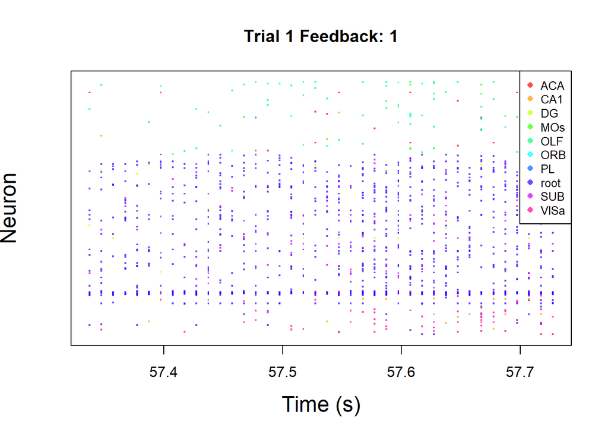

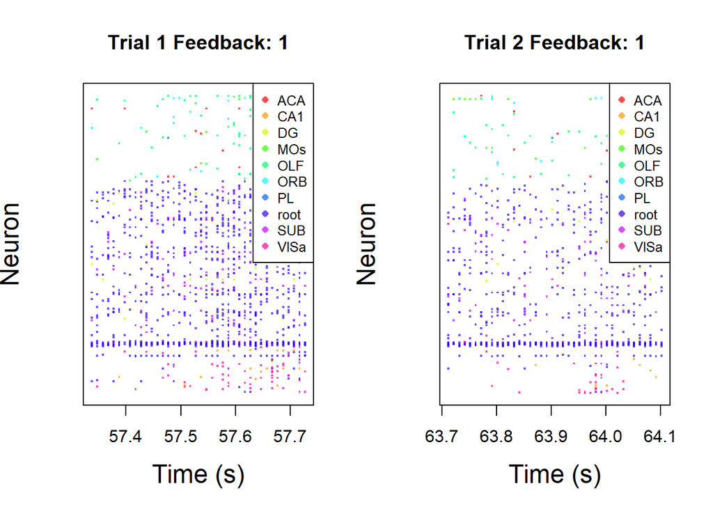

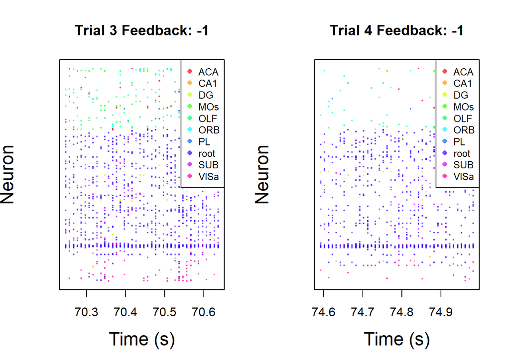

- To explore the changes across trials, I plot the activities of all neurons in the first 4 trials of session 5. Each plot represents a trial, and the y-axis represents the neurons, while the x-axis represents time in seconds. The time window for all 4 plots is 0.4 seconds. These four plots display spike patterns as individual dots along the y-axis, representing the occurrence of spikes for each neuron at specific time points. Neurons with higher spike rates will have more dots in their corresponding rows. Spike rates refers to the frequency or rate at which a neuron generates action potentials(spikes), and they are indirectly represented by the density and distribution of dots along the y-axis. Neurons with higher spike rates will have more dots or a denser concentration of spikes, indicating a higher frequency of action potentials. The feedback value for trial 1 and trial 2 is 1 and the feedback value for trial 3 and trial 4 is -1. In each session, visual stimuli were randomly presented to the mouse on two screens positioned on both sides of it. The mice were required to make decisions based on the visual stimuli, using a wheel controlled by their forepaws. The feedback value 1 means the mouse made a correct decision in a trial, and feedback value -1 means the mouse fails to make the decision we expect. From the plots, we can see that the mouse gives correct feedback in trial 1 and trial 2, and it response incorrectly in trial 3 and trial 4.By observing the plots of these 4 trials, we can see that neurons in brain areas with higher average spike counts such as root and SUB display higher spike rates no matter the feedback value is 1 or -1. The neuron patterns for other brain areas don’t change too much across the first 4 trials in session 5. Therefore, we still can’t conclude the relationship between neural responses and feedback. We can’t say that neurons with higher spike rates in brain areas like root and SUB tend to make mouse do the correct decision. We can say that brain areas root and SUB engage more with decision-making process of mouse when the visual stimuli is presented to the mouse.
4. Explore homogeneity and heterogeneity across sessions and mice.

```
## # A tibble: 1 × 4
##   Avg_Num_Areas Avg_Num_Neurons Avg_Num_Trials Avg_Success_Rate
##           <dbl>           <dbl>          <dbl>            <dbl>
## 1           9.5            906.           282.            0.707
```

- This table shows the average number of brain areas for 18 sessions, average of neurons numbers of 18 sessions, average trials did per session, and average rate that mice giving the expecting feedback across 18 sessions.

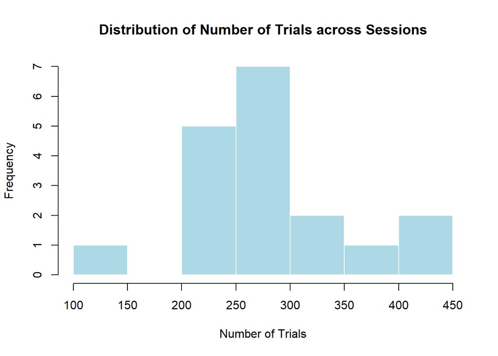

- In this distribution plot, we can visually see that there 6 different intervals for the number of trials completed across 18 sessions, and we can also observe the number of sessions related to each trials number interval.

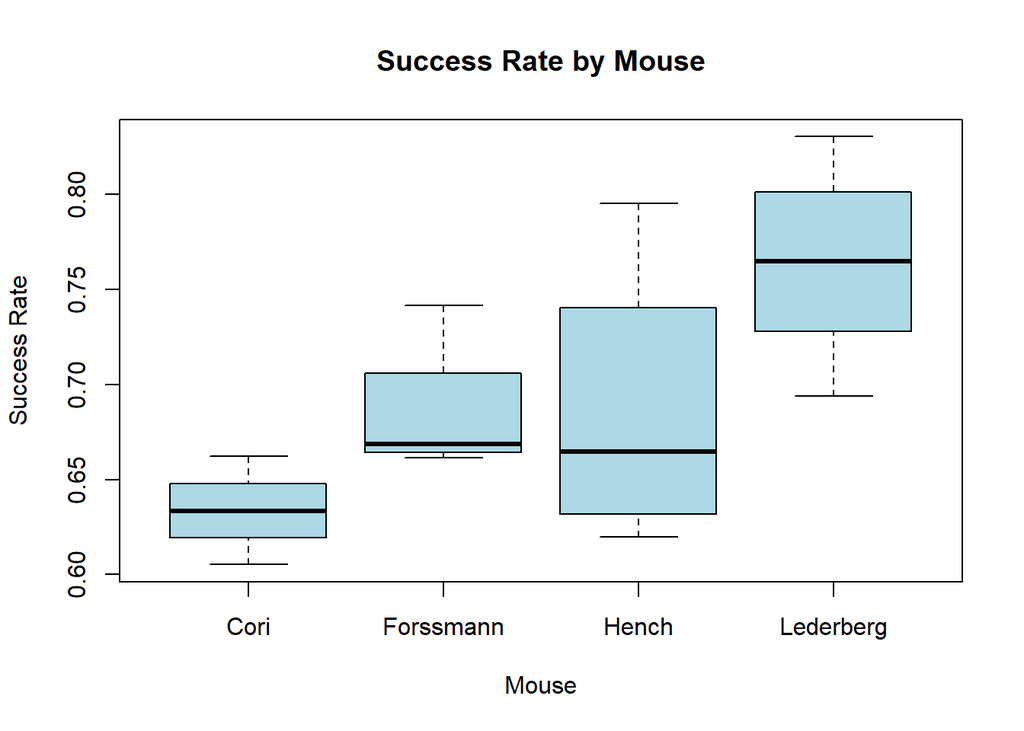

- This box plot shows the success rate by mouse. From table in section 4.1, we know that there are 3 sessions for mouse Cori, 4 sessions for mouse Forssmann, 4 sessions for mouse Hench, and 7 sessions for mouse Lederberg. Based on the data from sessions designed for each mouse, mouse Lederberg has the highest success rate to give the feedback we expect and mouse Cori has the lowest success rate to give the feedback we expect. The median success rate of Forssmann is similar to that of Hench, but Hench’s success rate has a higher upper limit than Frossmann’s.

```
## # A tibble: 4 × 5
##   Mouse_Name Avg_Num_Areas Avg_Num_Neurons Avg_Num_Trials Avg_Success_Rate
##   <chr>              <dbl>           <dbl>          <dbl>            <dbl>
## 1 Cori                8               808.           198.            0.634
## 2 Forssmann           8.5            1150.           261.            0.685
## 3 Hench              11.5             994.           353.            0.686
## 4 Lederberg           9.57            758.           290.            0.764
```

- This table express specific data values across mice by extracting information from sessions designed for each mouse. The average brain areas number of Hench and the average trials number completed for sessions of Hench is highest compare to other three mice, but the average success rate of Hench is not the highest within 4 mice. Lederberg, the mouse with the least average neurons number, has higher average success rate than the other 3 mice. My hypothesis is that how many brain areas a mouse has and how many trials a mouse completed are not main factors to decide the success rate or feedback type. More brain areas does not necessarily lead to higher success rate of a mouse’s choice, while fewer neurons may have made it easier to make the correct decision. In other word, not every brain area plays a helpful role in a mouse’s decision making. Only neurons and neuron activities in a certain brain area contribute most to the correct feedback.

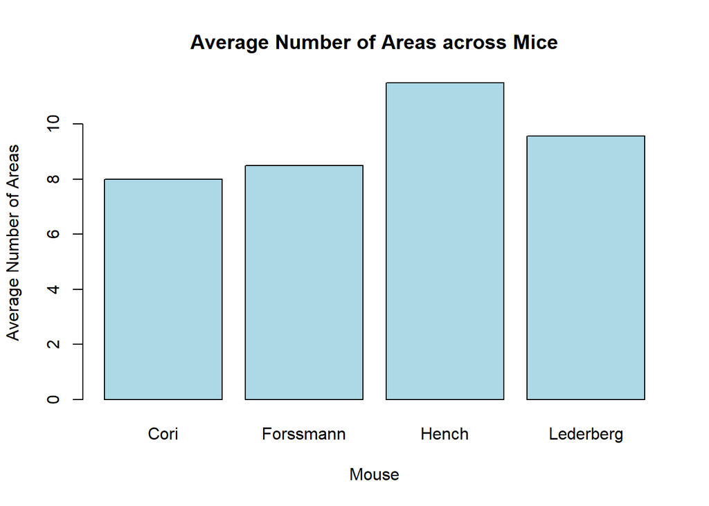

- Each mouse has an average brain areas number across its own sessions. In this plot of average number of areas across mice, we can directly tell that mouse Hench has highest average number of brain areas, and mouse Cori has lowest average number of brain areas. However, even the success rate of Cori is also the lowest within 4 mice, we can’t conclude the correlation of average number of brain areas and the success rate of mouse so far.

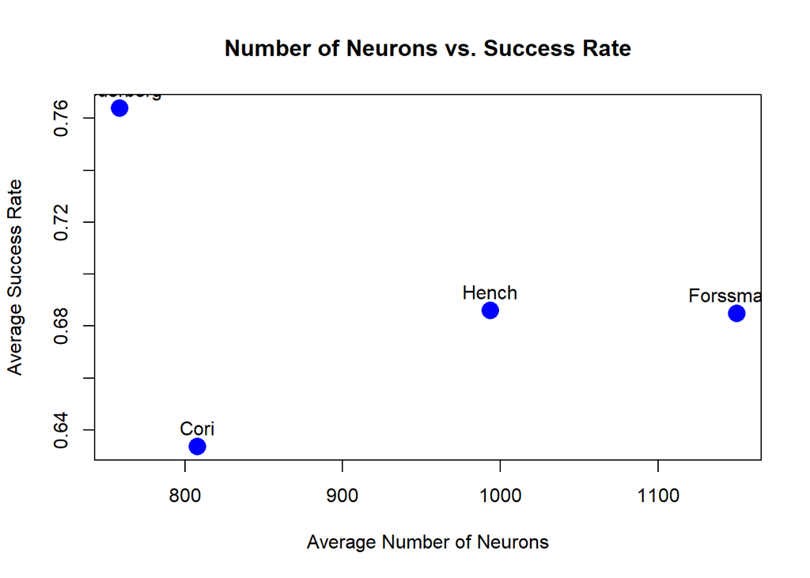

- This plot shows the relationship between the average number of neurons and the average success rate. The average number of neurons for mouse Hench is more than that for mouse Cori, and the average success rate of Hench is higher than that of Cori. In the other hand, the average number of neurons for mouse Forssmann is more than that for mouse Hench, but their average success rate is almost the same. Lederberg has the lowest average number of neurons, but its average success rate is the highest within 4 mice. I assume that adding or reducing the number of neurons is not that important to a mouse’s decision. Only neurons in a certain brain area contribute most to the correct feedback. The other neurons in other brain areas of the mouse is not that helpful for mouse to response well.

```
## # A tibble: 10 × 3
##    Avg_Spike_Count Min_Spike_Count Max_Spike_Count
##              <dbl>           <dbl>           <dbl>
##  1           0.280          0.0377           0.849
##  2           0.523          0.0357           1.39
##  3           1.34           0.375            2.75
##  4           0.386          0.0345           1
##  5           0.311          0.0994           0.762
##  6           0.292          0.0312           0.656
##  7           0.217          0                1.64
##  8           1.76           1.16             2.43
##  9           0.902          0.416            1.49
## 10           0.572          0.172            1.31
```

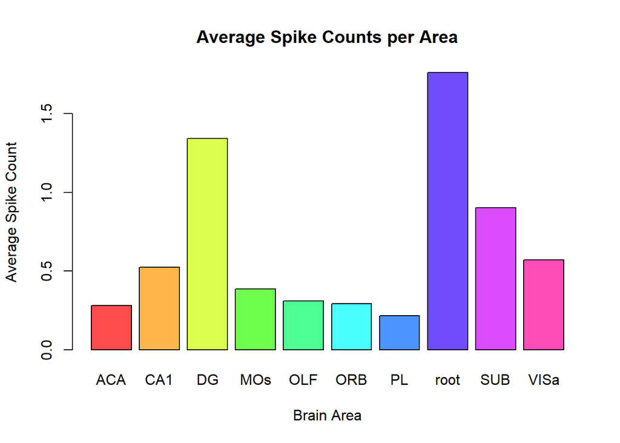

## 5 Data Integration

1. Calculating average spike counts during a trial.

```
## [1] 1.581744
```

- I learned this Benchmark method from course project consulting. Our goal in the project is to predict the outcome ( like feedback type) in the test set that contains 100 trials from Session 1 and Session 18. Based on our exploration in previous sections, we know that data structure differs across sessions since number of neurons, number of brain areas, and number of trials are different across 18 sessions. The heterogeneity is due to the differences in neurons measured in each session, so we can ignore the information about specific neurons by averaging over their activities by using this benchmark method. For each trial in a session, we can first take the summation of spikes for each neuron, which results in a vector that contains the total number of spikes for all neurons during the 0.4 seconds in that trial, and then we take the average of the total number of spikes, which results in one number that is the average spike counts during that trial.
2. Creating a table to show specific information of a session.

| ACA | CA1 | DG | MOs | OLF | ORB | PL | root | SUB | VISa | feedback | left_contr. | right_contr. | id | avg_spikes |
| --- | --- | --- | --- | --- | --- | --- | --- | --- | --- | --- | --- | --- | --- | --- |
| 0.30 | 0.64 | 1.44 | 0.24 | 0.33 | 0.38 | 0.21 | 2.10 | 1.01 | 0.70 | 1 | 0.00 | 1.00 | 1 | 1.31 |
| 0.19 | 0.25 | 0.94 | 0.41 | 0.26 | 0.31 | 0.07 | 1.40 | 0.58 | 0.34 | 1 | 0.00 | 0.00 | 2 | 0.86 |
| 0.45 | 0.18 | 1.19 | 0.83 | 0.63 | 0.47 | 0.71 | 1.90 | 0.95 | 0.63 | -1 | 0.25 | 0.25 | 3 | 1.27 |
| 0.11 | 0.18 | 1.12 | 0.31 | 0.23 | 0.25 | 0.21 | 1.38 | 0.58 | 0.38 | -1 | 0.00 | 0.00 | 4 | 0.85 |
| 0.19 | 0.71 | 1.44 | 0.48 | 0.23 | 0.38 | 0.14 | 1.96 | 1.13 | 0.90 | 1 | 0.00 | 0.00 | 5 | 1.26 |
| 0.19 | 0.57 | 1.31 | 0.34 | 0.41 | 0.12 | 0.00 | 2.08 | 1.09 | 0.87 | 1 | 0.50 | 1.00 | 6 | 1.32 |
| 0.21 | 0.71 | 2.31 | 0.31 | 0.26 | 0.09 | 0.21 | 2.33 | 1.38 | 0.85 | 1 | 0.00 | 0.50 | 7 | 1.46 |
| 0.19 | 0.89 | 2.25 | 0.17 | 0.31 | 0.28 | 0.14 | 2.28 | 1.25 | 1.04 | 1 | 0.50 | 1.00 | 8 | 1.46 |
| 0.21 | 0.54 | 1.44 | 0.28 | 0.31 | 0.16 | 0.43 | 2.27 | 1.32 | 0.78 | 1 | 0.50 | 1.00 | 9 | 1.42 |
| 0.53 | 0.75 | 1.00 | 0.59 | 0.57 | 0.44 | 0.36 | 1.98 | 1.16 | 0.91 | 1 | 0.25 | 1.00 | 10 | 1.35 |
| 0.38 | 0.29 | 1.19 | 0.55 | 0.46 | 0.28 | 0.29 | 1.81 | 0.94 | 0.62 | 1 | 1.00 | 0.00 | 11 | 1.17 |
| 0.32 | 0.50 | 1.19 | 0.45 | 0.51 | 0.47 | 0.14 | 1.97 | 1.12 | 0.72 | 1 | 0.25 | 0.50 | 12 | 1.29 |
| 0.30 | 0.18 | 0.81 | 0.21 | 0.35 | 0.16 | 0.07 | 1.75 | 1.07 | 0.23 | -1 | 0.00 | 0.25 | 13 | 1.08 |
| 0.25 | 0.82 | 1.25 | 0.28 | 0.41 | 0.28 | 0.43 | 2.37 | 0.99 | 0.88 | 1 | 1.00 | 1.00 | 14 | 1.47 |
| 0.26 | 0.71 | 1.62 | 0.31 | 0.27 | 0.28 | 0.29 | 1.97 | 0.95 | 0.63 | 1 | 1.00 | 0.00 | 15 | 1.22 |
| 0.19 | 0.46 | 1.56 | 0.21 | 0.20 | 0.16 | 0.14 | 2.18 | 0.98 | 1.00 | 1 | 1.00 | 0.25 | 16 | 1.34 |
| 0.21 | 0.21 | 1.69 | 0.59 | 0.28 | 0.34 | 0.14 | 1.98 | 0.81 | 0.51 | 1 | 0.50 | 0.00 | 17 | 1.20 |
| 0.32 | 1.32 | 1.56 | 0.34 | 0.45 | 0.38 | 0.50 | 2.30 | 1.20 | 1.03 | -1 | 0.50 | 0.50 | 18 | 1.50 |
| 0.26 | 0.21 | 1.38 | 0.48 | 0.20 | 0.19 | 0.07 | 1.75 | 0.95 | 0.41 | -1 | 0.25 | 0.50 | 19 | 1.07 |
| 0.38 | 0.39 | 1.56 | 0.45 | 0.35 | 0.25 | 0.43 | 1.91 | 0.93 | 0.51 | -1 | 0.25 | 1.00 | 20 | 1.20 |
| 0.45 | 0.71 | 1.50 | 0.76 | 0.49 | 0.47 | 0.43 | 2.04 | 0.77 | 0.97 | 1 | 0.25 | 1.00 | 21 | 1.34 |
| 0.28 | 0.96 | 2.19 | 0.52 | 0.26 | 0.53 | 0.21 | 2.28 | 1.18 | 0.74 | 1 | 0.00 | 1.00 | 22 | 1.43 |
| 0.30 | 0.75 | 1.88 | 0.38 | 0.29 | 0.34 | 0.79 | 1.92 | 0.75 | 0.74 | 1 | 1.00 | 0.00 | 23 | 1.22 |
| 0.30 | 0.21 | 1.12 | 0.41 | 0.26 | 0.19 | 0.14 | 1.66 | 0.60 | 0.25 | -1 | 0.50 | 0.25 | 24 | 0.99 |
| 0.34 | 0.11 | 1.94 | 0.28 | 0.16 | 0.31 | 0.29 | 2.09 | 1.39 | 0.46 | 1 | 0.00 | 0.00 | 25 | 1.28 |
| 0.26 | 0.89 | 1.12 | 0.24 | 0.25 | 0.25 | 0.21 | 2.27 | 1.10 | 0.91 | 1 | 0.25 | 1.00 | 26 | 1.40 |
| 0.23 | 0.54 | 1.25 | 0.45 | 0.30 | 0.22 | 0.21 | 1.94 | 0.76 | 0.79 | 1 | 0.50 | 0.00 | 27 | 1.20 |
| 0.26 | 0.75 | 2.00 | 0.34 | 0.21 | 0.22 | 0.00 | 2.24 | 0.95 | 0.86 | -1 | 0.25 | 0.00 | 28 | 1.37 |
| 0.34 | 0.21 | 1.12 | 0.62 | 0.33 | 0.38 | 0.07 | 1.73 | 1.04 | 0.32 | -1 | 0.25 | 0.25 | 29 | 1.09 |
| 0.34 | 0.14 | 0.81 | 0.52 | 0.37 | 0.22 | 0.07 | 1.48 | 0.56 | 0.33 | -1 | 0.25 | 0.50 | 30 | 0.92 |

[output cut: 224 more lines]

- When I know how to calculate average spike counts during a trial, I create a table to display more detail information in a session, taking session 5 as an example. From the table, we can see that there are 10 brain areas and 254 trials in session 5. The values in the columns of brain areas indicates the average number of spikes recorded across all neurons in a specific brain area during a given trial. It provides an indication of the overall level of neuronal activity in that area during the trial. The “avg_spikes” column provides the overall average spike count for each trial, regardless of the brain area. If we take a specific trial, the “avg_spikes” value will give us the average spike count across all brain areas combined. Left Contrast is the contrast level associated with the left stimulus during the trial. This value represents the strength or intensity of the stimulus presented on the left side. Similarly, Right Contrast is the contrast level associated with the right stimulus during the trial. This value represents the strength or intensity of the stimulus presented on the right side. The feedback type associated with the trial, and it indicates the outcome or response received from the mouse during the trial. This is binary, indicating correct(1) or incorrect(-1) feedback.Trial id is an unique identifier for each trial, and it allows us to track and identify individual trials. We can use this table to compare the average spike activity across different brain areas within each trial and summarize how the overall average spike count for each trial is related to the feedback outcome. In a general trend, the overall average spike count for each trial tend to be higher when the mouse gives a correct feedback(labeled with value 1). Therefore, combining all the information of spikes activity across 10 brain areas in each trial, we can say that even though each brain area has different levels of neuronal activity, a higher level of activity across the whole brain made the mouse more likely to make the right decision.
3. Visualization of average spike counts per brain area in session 5.

[figure not shown]

[figure not shown]

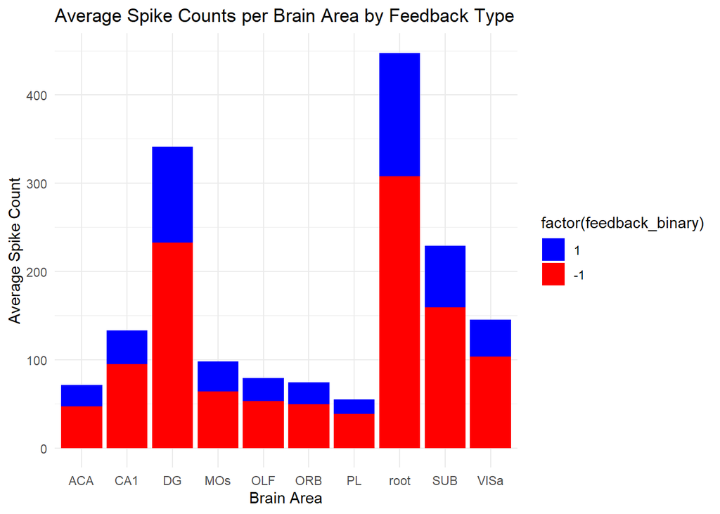

## 6 Predictive modeling

```
##   average_spike_area contrast feedback id
## 1                  5      0.7        1  3
## 2                  0                 0  0
## 3                  0                 0  0
```

```
##
## Call:
## lm(formula = feedback ~ contrast + average_spike_area, data = trial.summary)
##
## Residuals:
## 1 2 3
## 0 0 0
##
## Coefficients: (1 not defined because of singularities)
##                    Estimate Std. Error t value Pr(>|t|)
## (Intercept)               0          0     NaN      NaN
## contrast0.7               1          0     Inf   <2e-16 ***
## average_spike_area       NA         NA      NA       NA
## ---
## Signif. codes:  0 '***' 0.001 '**' 0.01 '*' 0.05 '.' 0.1 ' ' 1
##
## Residual standard error: 0 on 1 degrees of freedom
## Multiple R-squared:      1,  Adjusted R-squared:      1
## F-statistic:   Inf on 1 and 1 DF,  p-value: < 2.2e-16
```

```
## [1] FALSE
```

```
##
## Call:
## glm(formula = feedback ~ contrast + average_spike_area, family = binomial,
##     data = test_summary)
##
## Deviance Residuals:
##        Min          1Q      Median          3Q         Max
## -0.0087265  -0.0010214   0.0008343   0.0017169   0.0028893
##
## Coefficients:
##                      Estimate Std. Error z value Pr(>|z|)
## (Intercept)         -4.691925   4.516536  -1.039    0.299
## contrast             0.003497   0.712457   0.005    0.996
## average_spike_area  40.540870 165.378198   0.245    0.806
##
## (Dispersion parameter for binomial family taken to be 1)
##
##     Null deviance: 0.06398563  on 99  degrees of freedom
## Residual deviance: 0.00061969  on 97  degrees of freedom
## AIC: 11.396
##
## Number of Fisher Scoring iterations: 7
```

## Code Appendix

```r
# Load required libraries
suppressWarnings(library(tidyverse))
suppressWarnings(library(knitr))
suppressWarnings(library(dplyr))
# Set working directory
setwd("C:/Users/fangw/Downloads/")

# Create a "Data" folder in the same directory if it doesn't exist
dir.create("Data", showWarnings = FALSE)

# Copy the downloaded "sessions.zip" file to the "Data" folder
file.copy("sessions.zip", "Data/sessions.zip")

# Unzip the "sessions.zip" file within the "Data" folder
unzip("Data/sessions.zip", exdir = "Data")

# Read session data
session <- list()
for(i in 1:18) {
  session[[i]] <- readRDS(paste('./Data/session', i, '.rds', sep=''))
}
n.session <- length(session)
meta <- tibble(
  Mouse_Name = character(n.session),
  Date_Exp = character(n.session),
  Num_Areas = integer(n.session),
  Num_Neurons = integer(n.session),
  Num_Trials = integer(n.session),
  Success_Rate = numeric(n.session)
)

for(i in 1:n.session){
  tmp <- session[[i]]
  meta[i, "Mouse_Name"] <- tmp$mouse_name
  meta[i, "Date_Exp"] <- tmp$date_exp
  meta[i, "Num_Areas"] <- length(unique(tmp$brain_area))
  meta[i, "Num_Neurons"] <- dim(tmp$spks[[1]])[1]
  meta[i, "Num_Trials"] <- length(tmp$feedback_type)
  meta[i, "Success_Rate"] <- mean(tmp$feedback_type+1)/2
}
kable(meta, format = "html", table.attr = "class='table table-striped'", digits = 2)
# Define a function to calculate average spike counts for each area during a trial
average_spike_area <- function(i.t, this_session) {
  spk.trial <- this_session$spks[[i.t]]
  area <- this_session$brain_area
  spk.count <- apply(spk.trial, 1, sum)
  spk.average.tapply <- tapply(spk.count, area, mean)
  return(spk.average.tapply)
}

# Select a session and initialize the trial summary matrix
i.s <- 5
selected_session <- session[[i.s]]
n.trial <- length(selected_session$feedback_type)
n.area <- length(unique(selected_session$brain_area))
trial.summary <- matrix(nrow = n.trial, ncol = n.area + 1 + 2 + 1)

# Fill the trial summary matrix with average spike counts, feedback type, contrasts, and trial ID
for (i.t in 1:n.trial) {
  trial.summary[i.t, ] <- c(average_spike_area(i.t, this_session = selected_session),
                            selected_session$feedback_type[i.t],
                            selected_session$contrast_left[i.t],
                            selected_session$contrast_right[i.t],
                            i.t)
}

# Set column names and convert trial summary to a tibble
colnames(trial.summary) <- c(names(average_spike_area(i.t, this_session = selected_session)), 'feedback', 'left_contr.', 'right_contr.', 'id')
trial.summary <- as_tibble(trial.summary)

# Plotting
area.col <- rainbow(n = n.area, alpha = 0.7)
plot(x = 1, y = 0, col = 'white', xlim = c(0, n.trial), ylim = c(0.5, 2.2),
     xlab = "Trials", ylab = "Average Spike Counts",
     main = paste("Average Spike Counts per Area - Session", i.s))

for (i in 1:n.area) {
  lines(y = trial.summary[[i]], x = trial.summary$id, col = area.col[i], lty = 2, lwd = 1)
  lines(smooth.spline(trial.summary$id, trial.summary[[i]]), col = area.col[i], lwd = 3)
}

legend("topright", legend = colnames(trial.summary)[1:n.area], col = area.col, lty = 1, cex = 0.8)

# Add information about feedback type, contrasts, and trial ID to the plot
text(x = n.trial, y = 1.8, labels = paste("Feedback Type:", trial.summary$feedback), pos = 4)
text(x = n.trial, y = 1.6, labels = paste("Left Contrast:", trial.summary$left_contr.), pos = 4)
text(x = n.trial, y = 1.4, labels = paste("Right Contrast:", trial.summary$right_contr.), pos = 4)
text(x = n.trial, y = 1.2, labels = paste("Trial ID:", trial.summary$id), pos = 4)
print(trial.summary[, 1:n.area])
# Calculate the average spike counts for all trials in each brain area
average_spikes <- colMeans(trial.summary[, 1:n.area])

# Print the average spike counts per brain area
print(average_spikes)
plot.trial <- function(i.t, area, area.col, this_session) {
  spks <- this_session$spks[[i.t]]
  n.neuron <- dim(spks)[1]
  time.points <- this_session$time[[i.t]]

  plot(0, 0, xlim = c(min(time.points), max(time.points)), ylim = c(0, n.neuron + 1), col = 'white',
       xlab = 'Time (s)', yaxt = 'n', ylab = 'Neuron',
       main = paste('Trial', i.t, 'Feedback:', this_session$feedback_type[i.t]), cex.lab = 1.5)

  for (i in 1:n.neuron) {
    i.a <- which(area == this_session$brain_area[i])
    col.this <- area.col[i.a]

    ids.spike <- which(spks[i, ] > 0)  # find out when there are spikes
    if (length(ids.spike) > 0) {
      points(x = time.points[ids.spike], y = rep(i, length(ids.spike)), pch = '.', cex = 2, col = col.this)
    }
  }

  legend("topright",
         legend = area,
         col = area.col,
         pch = 16,
         cex = 0.8)
}

# Plot the activities of all neurons in the first trial of Session 5
varname <- names(trial.summary)
area <- varname[1:(length(varname) - 4)]
plot.trial(1, area, area.col, session[[i.s]])

# Plot the activities of all neurons in the first four trials of Session 5 side by side
varname <- names(trial.summary)
area <- varname[1:(length(varname) - 4)]
par(mfrow = c(1, 2))
plot.trial(1, area, area.col, session[[i.s]])
plot.trial(2, area, area.col, session[[i.s]])
plot.trial(3, area, area.col, session[[i.s]])
plot.trial(4, area, area.col, session[[i.s]])

par(mfrow = c(1, 1))
session_stats <- meta %>%
  summarise(
    Avg_Num_Areas = mean(Num_Areas),
    Avg_Num_Neurons = mean(Num_Neurons),
    Avg_Num_Trials = mean(Num_Trials),
    Avg_Success_Rate = mean(Success_Rate)
  )

print(session_stats)
# Visualize the distribution of the number of trials across sessions
hist(meta$Num_Trials, breaks = 10, col = "lightblue", border = "white",
     main = "Distribution of Number of Trials across Sessions",
     xlab = "Number of Trials")
# Create a boxplot to compare the success rates across sessions
boxplot(Success_Rate ~ factor(Mouse_Name), data = meta,
        col = "lightblue", border = "black",
        main = "Success Rate by Mouse",
        xlab = "Mouse", ylab = "Success Rate")
# Calculate summary statistics across mice
mouse_stats <- meta %>%
  group_by(Mouse_Name) %>%
  summarise(
    Avg_Num_Areas = mean(Num_Areas),
    Avg_Num_Neurons = mean(Num_Neurons),
    Avg_Num_Trials = mean(Num_Trials),
    Avg_Success_Rate = mean(Success_Rate)
  )
```

```r
print(mouse_stats)
# Visualize the distribution of the number of areas across mice
barplot(mouse_stats$Avg_Num_Areas, names.arg = mouse_stats$Mouse_Name,
        col = "lightblue", border = "black",
        main = "Average Number of Areas across Mice",
        xlab = "Mouse", ylab = "Average Number of Areas")
# Create a scatter plot to compare the number of neurons and success rates across mice
plot(mouse_stats$Avg_Num_Neurons, mouse_stats$Avg_Success_Rate,
     col = "blue", pch = 16, cex = 2,
     main = "Number of Neurons vs. Success Rate",
     xlab = "Average Number of Neurons", ylab = "Average Success Rate")

# Add labels for each point
text(mouse_stats$Avg_Num_Neurons, mouse_stats$Avg_Success_Rate,
     labels = mouse_stats$Mouse_Name, pos = 3)
# Calculate summary statistics for each brain area
area_stats <- trial.summary %>%
  summarise(
    Avg_Spike_Count = colMeans(across(1:n.area)),
    Min_Spike_Count = apply(across(1:n.area), 2, min),
    Max_Spike_Count = apply(across(1:n.area), 2, max)
  )

print(area_stats)
# Visualize the average spike counts per area across trials
barplot(area_stats$Avg_Spike_Count, names.arg = colnames(trial.summary)[1:n.area],
        col = area.col, border = "black",
        main = "Average Spike Counts per Area",
        xlab = "Brain Area", ylab = "Average Spike Count")

spks.trial=session[[1]]$spks[[1]]
total.spikes=apply(spks.trial,1,sum)
(avg.spikes=mean(total.spikes))
i.s <- 5
selected_session <- session[[i.s]]
n.trial <- length(selected_session$feedback_type)
n.area <- length(unique(selected_session$brain_area))
trial.summary <- matrix(nrow = n.trial, ncol = n.area + 1 + 2 + 1 + 1)

# Fill the trial summary matrix with average spike counts, feedback type, contrasts, trial ID, and additional information
for (i.t in 1:n.trial) {
  spks.trial <- selected_session$spks[[i.t]]
  total.spikes <- apply(spks.trial, 1, sum)
  avg.spikes <- mean(total.spikes)

  trial.summary[i.t, ] <- c(average_spike_area(i.t, this_session = selected_session),
                            selected_session$feedback_type[i.t],
                            selected_session$contrast_left[i.t],
                            selected_session$contrast_right[i.t],
                            i.t,
                            avg.spikes)
}

# Set column names and convert trial summary to a tibble
colnames(trial.summary) <- c(names(average_spike_area(i.t, this_session = selected_session)), 'feedback', 'left_contr.', 'right_contr.', 'id', 'avg_spikes')
trial.summary <- as_tibble(trial.summary)

# Print the trial summary
kable(trial.summary, format = "html", table.attr = "class='table table-striped'", digits = 2)
# Load required libraries
library(ggplot2)

# Identify the columns that correspond to brain areas
area_cols <- colnames(trial.summary)[1:n.area]

# Convert the trial.summary table to long format
trial_summary_long <- tidyr::pivot_longer(trial.summary, cols = all_of(area_cols), names_to = "Brain_Area", values_to = "Average_Spike_Count")

# Create a bar plot of average spike counts per brain area
ggplot(trial_summary_long, aes(x = Brain_Area, y = Average_Spike_Count, fill = Brain_Area)) +
  geom_bar(stat = "identity", position = "dodge") +
  labs(x = "Brain Area", y = "Average Spike Count", title = "Average Spike Counts per Brain Area") +
  theme_minimal()
# Create a new data frame to store the average spike counts per session and brain area
summary_data <- data.frame(Session = character(), Brain_Area = character(), Average_Spike_Count = numeric(), stringsAsFactors = FALSE)

# Iterate over sessions and extract the average spike counts
for (i.s in 1:n.session) {
  selected_session <- session[[i.s]]
  n.trial <- length(selected_session$feedback_type)
  n.area <- length(unique(selected_session$brain_area))

  # Calculate the average spike counts for all trials in each brain area
  average_spikes <- colMeans(trial.summary[, 1:n.area])

  # Create a data frame for the current session
  session_data <- data.frame(Session = rep(i.s, n.area),
                             Brain_Area = colnames(trial.summary)[1:n.area],
                             Average_Spike_Count = average_spikes)

  # Append the session data to the summary data frame
  summary_data <- rbind(summary_data, session_data)
}

# Create a bar plot of average spike counts per brain area across sessions
ggplot(summary_data, aes(x = Brain_Area, y = Average_Spike_Count, fill = factor(Session))) +
  geom_bar(stat = "identity", position = "dodge") +
  labs(x = "Brain Area", y = "Average Spike Count", title = "Average Spike Counts per Brain Area (Across Sessions)") +
  theme_minimal() +
  scale_fill_discrete(name = "Session")
# Load required libraries
library(ggplot2)

# Convert the trial.summary table to long format
trial_summary_long <- tidyr::pivot_longer(trial.summary, cols = all_of(area_cols), names_to = "Brain_Area", values_to = "Average_Spike_Count")

# Map the feedback type to two values: 1 and -1
trial_summary_long$feedback_binary <- ifelse(trial_summary_long$feedback == 1, 1, -1)

# Create a stacked bar plot of average spike counts per brain area and feedback type
ggplot(trial_summary_long, aes(x = Brain_Area, y = Average_Spike_Count, fill = factor(feedback_binary))) +
  geom_bar(stat = "identity", position = "stack") +
  labs(x = "Brain Area", y = "Average Spike Count", title = "Average Spike Counts per Brain Area by Feedback Type") +
  scale_fill_manual(values = c("blue", "red"), labels = c("1", "-1")) +
  theme_minimal()
# Define the necessary variables
session <- list(
  list(spks = list(c(1, 2, 3, 4, 5)), contrast = c(0.5, 0.7), feedback = 1, id = 1),
  list(spks = list(c(2, 3, 4, 5, 6)), contrast = c(0.6, 0.8), feedback = -1, id = 2),
  list(spks = list(c(3, 4, 5, 6, 7)), contrast = c(0.7, 0.9), feedback = 1, id = 3)
)

trial.summary <- data.frame(
  average_spike_area = numeric(length(session)),
  contrast = character(length(session)),
  feedback = numeric(length(session)),
  id = numeric(length(session))
)

area_cols <- c("trial_1", "trial_2", "trial_3", "trial_4", "trial_5")
```

```r
# Define the average_spike_area function
average_spike_area <- function(spks.trial) {
  mean(spks.trial)
}

# Calculate average spike area for each trial in each session
for (i.s in seq_along(session)) {
  selected_session <- session[[i.s]]
  for (i.t in seq_along(selected_session$spks)) {
    spks.trial <- selected_session$spks[[i.t]]
    trial.summary[i.t, ] <- c(average_spike_area(spks.trial), selected_session$contrast[i.t], selected_session$feedback, selected_session$id)
  }
}

# Print the trial summary
print(trial.summary)

# Build a prediction model using the trial summary data
# (Replace this part with your specific modeling steps)
model <- lm(feedback ~ contrast + average_spike_area, data = trial.summary)

# Print the model summary
summary(model)
# Set working directory
setwd("C:/Users/fangw/Downloads/")

# Copy the downloaded "test.zip" file to the "Data" folder
file.copy("test.zip", "Data/test.zip")

# Unzip the "test.zip" file within the "Data" folder
unzip("Data/test.zip", exdir = "Data")

# Read test data
test <- list()
for (i in 1:2) {
  test[[i]] <- readRDS(paste('./Data/test', i, '.rds', sep = ''))
}

# Extract relevant data from test sets
test_data <- list()
test_data[[1]] <- list(spks = test[[1]]$spks[1:100], contrast = test[[1]]$contrast[1:100], feedback = test[[1]]$feedback[1:100], id = test[[1]]$id[1:100])
test_data[[2]] <- list(spks = test[[2]]$spks[1:100], contrast = test[[2]]$contrast[1:100], feedback = test[[2]]$feedback[1:100], id = test[[2]]$id[1:100])

# Calculate average spike area for each trial in test sets
test_summary <- data.frame(
  average_spike_area = numeric(100),
  contrast = numeric(100),
  feedback = numeric(100),
  id = numeric(100)
)

for (i.s in 1:2) {
  selected_session <- test_data[[i.s]]
  for (i.t in 1:100) {
    spks.trial <- selected_session$spks[[i.t]]
    test_summary[i.t, ] <- c(average_spike_area(spks.trial), selected_session$contrast[i.t], selected_session$feedback[i.t], selected_session$id[i.t])
  }
}

# Build a prediction model using logistic regression
model <- glm(feedback ~ contrast + average_spike_area, data = test_summary, family = binomial)

# Print the model sum
summary(model)
sessionInfo()
```

## Acknowledgement

In this project, the data of 18 sessions (Sessions 1 to 18) from four mice (Cori, Frossman, Hence, and Lederberg) and the test data I used to test the model performance are all downloaded from the link provided in Canvas course page of STA 141A. I learned the background of mice experiment from html file of course project description in Canvas and the website https://doi.org/10.1038/s41586-019-1787-x. The code I used in this project is modified based on the code I learned from the html file of project consulting on 5/5/2023 (under week 5 on Canvas) and the html file of project consulting on 5/26/2023 (under week 8 on Canvas). Some code and analysis toward the model I used for the project is also modified based on the suggestions I learned from ChatGPT https://chat.openai.com/. Lectures materials and Jupyter notes in Canvas provide me thoughts to write the code too.

## Reference

- html file of course project description in Canvas
- html file of project consulting on 5/5/2023 (under week 5 on Canvas)
- html file of project consulting on 5/26/2023 (under week 8 on Canvas)
- Note of discussion about the function data analysis and tips for final project (under week 10 on Canvas)
- Steinmetz, N.A., Zatka-Haas, P., Carandini, M. et al. Distributed coding of choice, action and engagement across the mouse brain. Nature 576, 266–273 (2019). https://doi.org/10.1038/s41586-019-1787-x.
- Data sets download from sessions.zip link ( under file of course project description in Canvas)
- Test data download from test.zip link in Canvas